# The Z-Test

2025

## NHST Summary Recipe: Population Mean

1. Specify the null and alternative hypotheses (\(H_0\) and \(H_1\)) in terms of a the population mean \(\mu\).

\[ \begin{align} H_0: \mu &= \mu_0 \\ H_1: \mu &\neq \mu_0 \end{align} \]

## NHST Summary Recipe: Population Mean

1. Specify the type I error rate – denoted by the symbol \(\alpha\) – you are willing to tolerate.

\[ \alpha = 0.05 \]

## NHST Summary Recipe: Population Mean

1. Specify the sample statistic \(\widehat{\mu}\) that you will use to estimate the population parameter \(\mu\) in step 1 and state how it is distributed under the assumption that \(H_0\) is true.

\[ \widehat{\mu} = \overline{x} \sim \mathscr{N}(\mu_0, \frac{\sigma}{\sqrt{n}}) \]

## NHST Summary Recipe: Population Mean

1. Obtain a random sample and use it to compute the sample statistic from step 3. Call this value \(\widehat{\mu}_{\text{obs}}\).

\[ \begin{align} x_{\text{obs}} &= \{ x_1, x_2, \ldots, x_n \} \\ \widehat{\mu}_{\text{obs}} &= \overline{x}_{\text{obs}} = \frac{1}{n} \sum_{i=1}^{n} x_i \end{align} \]

## NHST Summary Recipe: Population Mean

1. If \(\widehat{\mu}_{\text{obs}}\) or a **more extreme outcome** is very unlikely to occur under the assumption that \(H_0\) is true, then reject \(H_0\). Otherwise, do not reject \(H_0\).

\[ P(\overline{X} \leq \overline{x}_{\text{obs}} | H_0) < \alpha \rightarrow \text{reject } H_0 \\\\ \text{Fail to reject } H_0 \text{ otherwise} \]

## NHST Summary Recipe: Arbitrary Parameter

1. Specify the null and alternative hypotheses (\(H_0\) and \(H_1\)) in terms of a population parameter \(\theta\).
2. Specify the type I error rate – denoted by the symbol \(\alpha\) – you are willing to tolerate.
3. Specify the sample statistic \(\widehat{\theta}\) that you will use to estimate the population parameter \(\theta\) in step 1 and state how it is distributed under the assumption that \(H_0\) is true.
4. Obtain a random sample and use it to compute the sample statistic from step 3. Call this value \(\widehat{\theta}_{\text{obs}}\).
5. If \(\widehat{\theta}_{\text{obs}}\) or a **more extreme outcome** is very unlikely to occur under the assumption that \(H_0\) is true, then reject \(H_0\). Otherwise, do not reject \(H_0\).

## What is \(\theta\) and \(\widehat{\theta}\)?

- \(\theta\) is a population parameter that you are interested in estimating. E.g., in the case of a Normal test, \(\theta\) is the population mean \(\mu\).
- \(\widehat{\theta}\) is a sample statistic that you use to estimate \(\theta\). E.g., in the case of a Normal test, \(\widehat{\theta}\) is the sample mean \(\overline{x}\).
- The reason we bother to write the steps in terms of \(\theta\) and \(\widehat{\theta}\) is that the steps are general and can be applied to any hypothesis test.

## How did we compute P-values before computers?

- Statistical tables were the primary tool for finding p-values before computers.
- Tables provided pre-calculated critical values and p-values for various distributions at common significance levels.
- Relevant test statistic would be calculated by hand based on the sample data and then looked up in the appropriate table to get the corresponding p-value.

## How many tables were there?

- Consider just the Normal distribution defined by a mean \(\mu_X\) and standard deviation \(\sigma_X\).
- There are infinitely many possible values for \(\mu_X\) and \(\sigma_X\), so there would be infinitely many tables.
- In practice only the **standard normal distribution** was tabulated.

## The Standard Normal (\(Z\)) Distribution

- The standard normal distribution is a normal distribution with a mean of 0 and a standard deviation of 1.

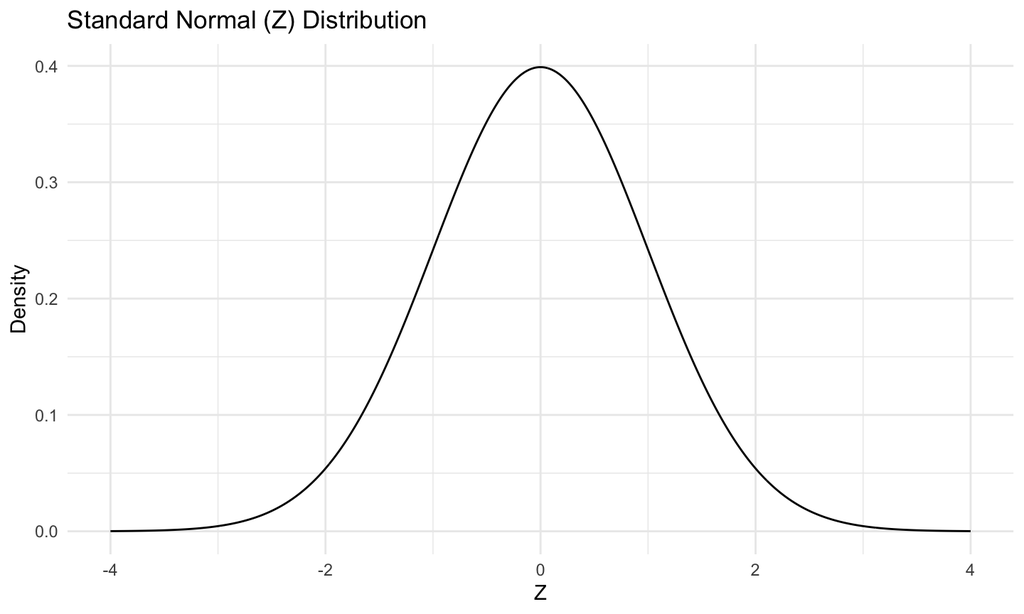

## The \(Z\) transformation

- Any normal distribution can be transformed into a standard normal distribution by subtracting the mean and dividing by the standard deviation.

\[ \begin{align} X &\sim \mathscr{N}(\mu_X, \sigma_X) \\ Z &= \frac{X - \mu_X}{\sigma_X} \\ Z &\sim \mathscr{N}(0, 1) \end{align} \]

## The \(Z\) transformation

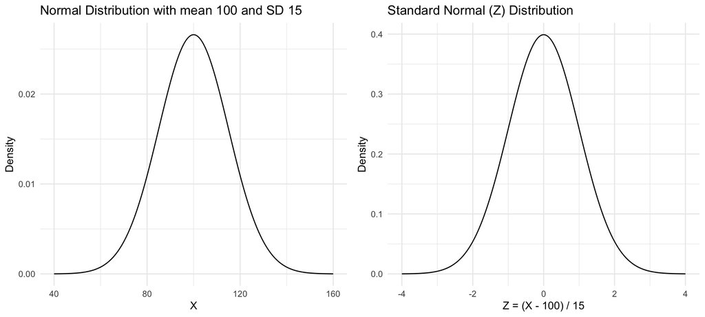

## The \(z\)-score

- \(z_{obs}\) is a single value that represents the number of standard deviations the single value \(x_{obs}\) is from \(\mu_X\).

\[ \begin{align} z_{obs} &= \frac{x_{obs} - \mu_X}{\sigma_X} \\ z_{obs} &\sim \mathscr{N}(0, 1) \end{align} \]

## The \(z\)-score

- A \(z\)-score is a generic term that refers to the \(Z\)-transformation of an observation from any random variable. But we will see it most commonly used in the context of the sample mean.

\[ \begin{align} z_{obs} &= \frac{\overline{x}_{obs} - \mu_\overline{X}}{\sigma_\overline{X}} \\ z_{obs} &\sim \mathscr{N}(0, 1) \end{align} \]

## A quick note on nomenclature

- We use capital letters to denote random variables and lower case letters to denote specific observations from those random variables.
- We may also use subscripts (e.g., \(z_{obs}\)) to further clarifiy whether we are referencing a random variable or a specific observation.
- Even if we neglect to perfectly follow this convention it will usually be clear from context which is which.

## Question

Given a normal distribution with a mean (\(\mu_X\)) of 100 and a standard deviation (\(\sigma_X\)) of 15, you calculate a sample mean (\(\overline{x}\)) of 108 from a random sample of size \(n=10\). What is the \(z\)-score for this sample mean?

**Click here for the answer**

\[ \begin{align} z_{obs} &= \frac{\overline{x} - \mu_{\overline{X}}}{\sigma_{\overline{X}}} \\ z_{obs} &= \frac{\overline{x} - \mu_{X}}{\sigma_{X} / \sqrt{n}} \\ z &= \frac{108 - 100}{15/\sqrt{10}}\\ z &= 1.69 \end{align} \]

## Question

What is true about the \(Z\)-transformed distribution of and \(X\) and \(\overline{X}\)?

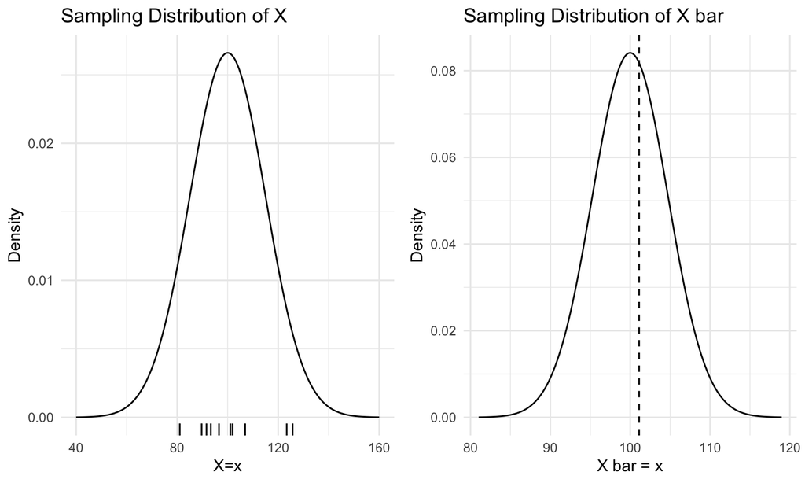

- The \(Z\)-transformed distribution of \(X\) is normal with a mean of 0 and a standard deviation of 1 but the \(Z\)-transformed distribution of \(\overline{X}\) is not.
- The \(Z\)-transformed distribution of \(\overline{X}\) is normal with a mean of 0 and a standard deviation of 1 but the \(Z\)-transformed distribution of \(X\) is not.
- They are both normal with a mean of 0 and a standard deviation of 1.
- Neither is normal with a mean of 0 and a standard deviation of 1.

**Click here for the answer**

- They are both normal with a mean of 0 and a standard deviation of 1.